# MNIST Object Detection Model Development and Improvement Using Roboflow and YOLO

## 1. Introduction

Object detection is a computer vision task that aims to identify both **what objects are present** in an image and **where they are located**. Unlike image classification, which assigns a single label to an entire image, object detection predicts one or more bounding boxes together with class labels for each detected object.

This project focuses on handwritten digit detection using a dataset derived from MNIST. The original MNIST dataset is one of the most widely used benchmark datasets in machine learning and is typically used for **image classification**, where a single handwritten digit appears in each image. However, in this project, the task was reformulated as an **object detection problem**, meaning that the model had to locate and classify multiple digit objects inside an image.

To accomplish this, Roboflow was used for dataset versioning, preprocessing, and augmentation management, while YOLO was used as the object detection model for training and evaluation. The purpose of this notebook is not only to train a detector, but also to document the full improvement process: starting from a baseline model, identifying a limitation in the default training setup, refining the augmentation strategy, and comparing multiple dataset versions to obtain a better final model.

## 2. Conceptual Background

### 2.1 Image Classification vs. Object Detection

Image classification and object detection solve related but fundamentally different problems.

In **image classification**, the model predicts one label for the entire image. For example, if an image contains a handwritten digit, the model predicts whether it is 0, 1, 2, or another class. In this setting, the model is not required to determine the location of the object.

In **object detection**, the model must predict:

- the class of each object
- the location of each object through a bounding box

Therefore, object detection is more complex than classification because it combines both recognition and localization.

In the context of this project, this distinction is important because MNIST is originally a classification dataset, while YOLO is an object detection model. As a result, the dataset had to be reorganized and exported in a detection-compatible format.

### 2.2 Why YOLO Was Used

YOLO, which stands for **You Only Look Once**, is a real-time object detection framework designed to perform object localization and classification in a single model pipeline. YOLO is widely used because it is efficient, relatively easy to train, and provides strong performance on detection tasks.

In this project, YOLO was chosen for three reasons:

1. It supports custom object detection datasets in a straightforward format.
2. It provides convenient training, validation, and prediction workflows.
3. It makes it easy to compare multiple experiments using the same model architecture and different dataset versions.

### 2.3 Why Roboflow Was Used

Roboflow was used as the dataset management platform for this project. Its role was especially important because the experiment involved multiple dataset versions rather than a single fixed dataset.

Roboflow was used for:

- annotation handling
- preprocessing
- augmentation setup
- dataset version generation
- export of training-ready object detection datasets

This version-based workflow made it possible to compare how different augmentation policies influenced final model performance.

## 3. Objective of the Study

The main objective of this study is to develop and improve a handwritten digit object detection model using Roboflow and YOLO.

More specifically, the study aims to:

1. establish a baseline detection model on the first dataset version
2. analyze the limitations of the default YOLO training configuration
3. test whether removing unsuitable augmentation improves digit detection performance
4. compare multiple dataset versions generated in Roboflow
5. identify the version that produces the most balanced object detection performance

Through this process, the notebook demonstrates not only final performance, but also the reasoning behind each improvement step.

## 4. Experimental Environment

Before conducting the experiments, the software environment was verified. The versions of Python, Ultralytics, and Roboflow were checked to ensure compatibility and reproducibility of the training pipeline.

The final training experiments were performed with GPU acceleration after confirming CUDA availability. This was important because multiple object detection experiments were conducted across several dataset versions, and GPU training significantly reduced execution time.

```python
import ultralytics
import roboflow
import sys

print("Python:", sys.version)
print("Ultralytics:", ultralytics.__version__)
print("Roboflow:", roboflow.__version__)
```

```
Python: 3.11.9 (tags/v3.11.9:de54cf5, Apr  2 2024, 10:12:12) [MSC v.1938 64 bit (AMD64)]
Ultralytics: 8.4.22
Roboflow: 1.2.16
```

## 5. Dataset Preparation and Structure Verification

Three dataset versions were prepared in advance:

- **V1**: initial baseline dataset
- **V2**: improved dataset with additional augmentation settings
- **V3**: further refined dataset version

Before training, the local directory structure and image counts for each dataset split were checked. This step was necessary to verify that all versions contained valid `train`, `valid`, and `test` folders and that the datasets were correctly exported from Roboflow.

```python
from pathlib import Path

DATASETS = {
    "v1": Path("./data/mnist/mnist_v1"),
    "v2": Path("./data/mnist/mnist_v2"),
    "v3": Path("./data/mnist/mnist_v3"),
}

IMAGE_EXTS = {".jpg", ".jpeg", ".png", ".bmp", ".webp"}

for name, path in DATASETS.items():
    print(f"\n===== {name} =====")
    print("resolved path:", path.resolve())
    print("exists:", path.exists())

    yaml_path = path / "data.yaml"
    train_img = path / "train" / "images"
    valid_img = path / "valid" / "images"
    test_img  = path / "test" / "images"

    print("data.yaml:", yaml_path.exists())
    print("train/images:", train_img.exists())
    print("valid/images:", valid_img.exists())
    print("test/images :", test_img.exists())

    def count_images(folder: Path):
        if not folder.exists():
            return 0
        return sum(1 for f in folder.iterdir() if f.suffix.lower() in IMAGE_EXTS)

    print("train image count:", count_images(train_img))
    print("valid image count:", count_images(valid_img))
    print("test  image count:", count_images(test_img))
```

```
===== v1 =====
resolved path: D:\workplace_00\data\mnist\mnist_v1
exists: True
data.yaml: True
train/images: True
valid/images: True
test/images : True
train image count: 35
valid image count: 10
test  image count: 5

===== v2 =====
resolved path: D:\workplace_00\data\mnist\mnist_v2
exists: True
data.yaml: True
train/images: True
valid/images: True
test/images : True
train image count: 104
valid image count: 10
test  image count: 5

===== v3 =====
resolved path: D:\workplace_00\data\mnist\mnist_v3
exists: True
data.yaml: True
train/images: True
valid/images: True
test/images : True
train image count: 105
valid image count: 10
test  image count: 5
```

```python
yaml_path = Path("./data/mnist/mnist_v1/data.yaml")
print(yaml_path.read_text(encoding="utf-8"))
```

```
train: ../train/images
val: ../valid/images
test: ../test/images

nc: 10
names: ['0', '1', '2', '3', '4', '5', '6', '7', '8', '9']

roboflow:
  workspace: jungkyus-workspace
  project: my-first-project-kh8et
  version: 1
  license: Public Domain
  url: https://universe.roboflow.com/jungkyus-workspace/my-first-project-kh8et/dataset/1
```

### Local YAML Configuration for Training

To ensure stable training in the local environment, a new `data_local.yaml` file was generated for each dataset version. In this configuration, the dataset paths were rewritten as follows:

- `train: train/images`
- `val: valid/images`
- `test: test/images`

This modification prevented path resolution errors during YOLO training and made the notebook portable across local executions.

```python
from pathlib import Path
import yaml

DATASET_ROOTS = {
    "v1": Path("./data/mnist/mnist_v1"),
    "v2": Path("./data/mnist/mnist_v2"),
    "v3": Path("./data/mnist/mnist_v3"),
}

for version_name, root in DATASET_ROOTS.items():
    orig_yaml = root / "data.yaml"
    local_yaml = root / "data_local.yaml"

    if not orig_yaml.exists():
        print(f"[{version_name}] data.yaml not found: {orig_yaml.resolve()}")
        continue

    with open(orig_yaml, "r", encoding="utf-8") as f:
        data = yaml.safe_load(f)

    data["train"] = "train/images"
    data["val"] = "valid/images"
    data["test"] = "test/images"

    with open(local_yaml, "w", encoding="utf-8") as f:
        yaml.safe_dump(data, f, allow_unicode=True, sort_keys=False)

    print(f"\n[{version_name}] saved -> {local_yaml.resolve()}")
    print(local_yaml.read_text(encoding="utf-8"))
```

```
[v1] saved -> D:\workplace_00\data\mnist\mnist_v1\data_local.yaml
train: train/images
val: valid/images
test: test/images
nc: 10
names:
- '0'
- '1'
- '2'
- '3'
- '4'
- '5'
- '6'
- '7'
- '8'
- '9'
roboflow:
  workspace: jungkyus-workspace
  project: my-first-project-kh8et
  version: 1
  license: Public Domain
  url: https://universe.roboflow.com/jungkyus-workspace/my-first-project-kh8et/dataset/1


[v2] saved -> D:\workplace_00\data\mnist\mnist_v2\data_local.yaml
train: train/images
val: valid/images
test: test/images
nc: 10
names:
- '0'
- '1'
- '2'
- '3'
- '4'
- '5'
- '6'
- '7'
- '8'
- '9'
```

[output cut: 15 more lines]

```
- '1'
- '2'
- '3'
- '4'
- '5'
- '6'
- '7'
- '8'
- '9'
roboflow:
  workspace: jungkyus-workspace
  project: my-first-project-kh8et
  version: 3
  license: Public Domain
  url: https://universe.roboflow.com/jungkyus-workspace/my-first-project-kh8et/dataset/3
```

## 6. Dataset Versions Used in This Study

Three dataset versions were prepared and used throughout the experiments. Each version reflects a different stage of the dataset design process.

### Version 1 (V1): Initial Baseline Dataset

Version 1 represents the original baseline dataset exported from Roboflow. This version was used to establish the initial reference performance of the model.

**Preprocessing**

- Auto-Orient applied

**Augmentation**

- No augmentation applied

V1 was intentionally kept simple in order to provide a clean baseline. It was first trained with the default YOLO configuration and later reused in the no-flip experiment to isolate the effect of the training policy.

### Version 2 (V2): Augmented Intermediate Dataset

Version 2 was created by adding augmentation settings in Roboflow. Compared with V1, this version increased the number of training images and introduced more variation into the training data.

**Preprocessing**

- Auto-Orient applied
- Resize: Stretch to 640×640

**Augmentation**

- Outputs per training example: 3
- Rotation: between -15° and +15°

Compared with V1, Version 2 increased the number of training images and introduced geometric variation through rotation. The purpose of this version was to improve robustness to orientation changes while preserving the overall semantic structure of handwritten digits.

### Version 3 (V3): Final Refined Dataset

Version 3 was the most refined dataset version used in this study. It built upon Version 2 by adding appearance-based augmentations in addition to rotation.

**Preprocessing**

- Auto-Orient applied
- Resize: Stretch to 640×640

**Augmentation**

- Outputs per training example: 3
- Rotation: between -15° and +15°
- Brightness: between -15% and +15%
- Exposure: between -15% and +15%
- Blur: up to 2.5 px

The purpose of Version 3 was to improve robustness not only to geometric variation but also to visual quality variation. By introducing brightness, exposure, and blur adjustments, this version aimed to make the detector more stable under less ideal visual conditions.

### Rationale for Version Progression

The three versions reflect a progressive experimental strategy:

- **V1** established the baseline using minimal preprocessing and no augmentation.
- **V2** introduced moderate geometric augmentation through resizing and rotation.
- **V3** extended this strategy by adding visual-condition augmentations such as brightness, exposure, and blur.

This progressive version design made it possible to analyze how controlled dataset refinement influenced final detection performance.

An important aspect of this study is that the dataset was not treated as fixed. Instead, multiple Roboflow versions were created with progressively refined preprocessing and augmentation settings. This allowed the experiment to evaluate not only model behavior, but also the effect of controlled dataset design choices.

## 7. Evaluation Metrics

To evaluate the object detection models, four main metrics were used throughout the experiments:

- **Precision**
- **Recall**
- **mAP50**
- **mAP50-95**

These metrics are standard in object detection, but they reflect different aspects of model performance. Therefore, understanding their meaning is essential for interpreting the experimental results.

### 7.1 Precision

**Precision** measures how many predicted detections are actually correct.

In simple terms, precision answers the question:

> When the model says there is a digit, how often is it correct?

A higher precision means that the model produces fewer false positives. In this project, high precision is important because incorrect digit predictions can reduce the reliability of the detector, especially when multiple digits appear in the same image.

### 7.2 Recall

**Recall** measures how many real objects in the image are successfully detected by the model.

In simple terms, recall answers the question:

> Out of all real digits present in the image, how many did the model find?

A higher recall means that the model misses fewer objects. In this project, recall is important because the detector should identify as many digit instances as possible, especially when several digits are present in one image.

### 7.3 mAP50

**mAP50** stands for mean Average Precision at an Intersection over Union threshold of 0.50.

This metric evaluates whether the predicted bounding box overlaps sufficiently with the ground-truth bounding box at a relatively lenient threshold. A higher mAP50 indicates that the model is performing well in terms of both classification and rough localization.

In this experiment, mAP50 is useful for understanding the model’s general detection capability.

### 7.4 mAP50-95

**mAP50-95** is a stricter and more comprehensive metric. It averages performance over multiple IoU thresholds from 0.50 to 0.95.

This means the metric evaluates not only whether the model detects the object, but also how accurately it localizes the object. Because of its stricter nature, mAP50-95 is usually lower than mAP50.

In this project, mAP50-95 is especially important because it reflects the overall quality of the final detector more reliably than a single-threshold metric.

### 7.5 Meaning of These Metrics in This Study

In the context of this project, each metric has a specific interpretive role:

- **Precision** indicates how reliable the detections are
- **Recall** indicates how many digit objects are successfully found
- **mAP50** indicates the overall detection quality at a standard threshold
- **mAP50-95** indicates the overall robustness and localization quality of the detector

Because this project compares several experimental conditions, the metrics should be interpreted together rather than individually. For example:

- a model with higher precision but lower recall may be more conservative
- a model with higher recall may detect more objects but also introduce more errors
- a model with higher mAP50-95 is generally considered more accurate and balanced overall

For this reason, the final model selection in this notebook is based on the combined interpretation of all four metrics rather than a single score alone.

## 8. Experimental Design Logic

The experiments in this notebook were designed as a step-by-step improvement process rather than a set of unrelated training trials.

The progression was as follows:

1. **V1 baseline**: establish the initial reference performance
2. **V1 no-flip**: test whether removing an unsuitable augmentation improves results
3. **V2 no-flip**: evaluate the effect of a more diverse augmented dataset
4. **V3 no-flip**: evaluate the final refined dataset version

This design makes it possible to separate two types of improvement:

- improvement caused by **training policy adjustment**
- improvement caused by **dataset version refinement**

As a result, the notebook captures not only which model performed best, but also why the performance improved over time.

## 9. Experiment 1: V1 Baseline Training

The first experiment used **Version 1** of the dataset as the baseline condition. This experiment was designed to establish the initial performance level of YOLO before introducing any task-specific correction.

At this stage, the model was trained using the default YOLO training behavior. This means the experiment reflects how a general-purpose object detection pipeline performs on the MNIST digit detection task without additional adjustment for domain-specific characteristics.

This baseline is important because all later experiments are evaluated relative to this starting point.

```python
from ultralytics import YOLO

model_v1 = YOLO("yolov8m.pt")

results_v1 = model_v1.train(
    data="./data/mnist/mnist_v1/data_local.yaml",
    epochs=100,
    patience=50,
    imgsz=640,
    batch=8,
    project="./runs/mnist",
    name="v1_baseline",
    exist_ok=True
)

best_model = YOLO("./runs/detect/runs/mnist/v1_baseline/weights/best.pt")

metrics = best_model.val(
    data="./data/mnist/mnist_v1/data_local.yaml",
    split="val",
    device=0
)

precision = metrics.box.mp
recall = metrics.box.mr
map50 = metrics.box.map50
map5095 = metrics.box.map

print("\n===== V1 No-Flip Validation Metrics =====")
print(f"Precision   : {precision:.4f}")
print(f"Recall      : {recall:.4f}")
print(f"mAP50       : {map50:.4f}")
print(f"mAP50-95    : {map5095:.4f}")
```

[output not shown]

[output cut: 537 more lines]

```
                     3          6          8      0.803       0.75      0.916      0.523
                     4          4          4          1      0.999      0.995       0.59
                     5          1          1      0.314          1      0.995      0.697
                     6          3          5      0.802      0.811      0.962      0.607
                     7          3          3      0.873          1      0.995      0.588
                     8          5          7      0.675          1      0.871      0.475
                     9          6          7      0.932          1      0.995      0.693
Speed: 1.0ms preprocess, 28.5ms inference, 0.0ms loss, 0.5ms postprocess per image
Results saved to D:\workplace_00\runs\detect\val11

===== V1 No-Flip Validation Metrics =====
Precision   : 0.7736
Recall      : 0.9357
mAP50       : 0.9636
mAP50-95    : 0.5978
```

### Result Interpretation

The baseline model achieved a reasonably strong initial performance, indicating that YOLO could learn the digit detection task even from a relatively small dataset. However, this experiment also served as a diagnostic stage, revealing that the default training configuration may include augmentations that are not fully suitable for handwritten digit detection.

## 10. Experiment 2: V1 Training Without Flip Augmentation

The second experiment reused **Version 1** of the dataset but changed the training policy by disabling flip augmentation.

This modification was introduced after recognizing that handwritten digits are fundamentally different from natural image objects. In natural image detection, horizontal flip is usually harmless or beneficial. In handwritten digit detection, however, a flipped digit may no longer represent a realistic or semantically correct example.

Therefore, this experiment was designed to test whether a more task-appropriate augmentation policy would improve detection quality even without changing the dataset version itself.

```python
from ultralytics import YOLO

model_v1_noflip = YOLO("yolov8m.pt")

results_v1_noflip = model_v1_noflip.train(
    data="./data/mnist/mnist_v1/data_local.yaml",
    epochs=100,
    patience=50,
    imgsz=640,
    batch=16,
    device=0,
    fliplr=0.0,
    flipud=0.0,
    project="./runs/mnist",
    name="v1_no_flip",
    exist_ok=True
)

best_model = YOLO("./runs/detect/runs/mnist/v1_no_flip/weights/best.pt")

metrics = best_model.val(
    data="./data/mnist/mnist_v1/data_local.yaml",
    split="val",
    device=0
)

precision = metrics.box.mp
recall = metrics.box.mr
map50 = metrics.box.map50
map5095 = metrics.box.map

print("\n===== V1 No-Flip Validation Metrics =====")
print(f"Precision   : {precision:.4f}")
print(f"Recall      : {recall:.4f}")
print(f"mAP50       : {map50:.4f}")
print(f"mAP50-95    : {map5095:.4f}")
```

[output not shown]

[output cut: 537 more lines]

```
                     3          6          8      0.889        0.5      0.923      0.548
                     4          4          4          1      0.877      0.995      0.564
                     5          1          1      0.466          1      0.995      0.697
                     6          3          5      0.799        0.8       0.88      0.542
                     7          3          3      0.974          1      0.995      0.559
                     8          5          7          1      0.758      0.995      0.622
                     9          6          7          1      0.964      0.995      0.736
Speed: 2.2ms preprocess, 43.6ms inference, 0.0ms loss, 0.5ms postprocess per image
Results saved to D:\workplace_00\runs\detect\val8

===== V1 No-Flip Validation Metrics =====
Precision   : 0.8715
Recall      : 0.8472
mAP50       : 0.9658
mAP50-95    : 0.6004
```

### Result Interpretation

Compared with the baseline model, the no-flip version improved precision, mAP50, and mAP50-95, while recall decreased. This indicates that removing horizontal flip augmentation made the detector more conservative but also more reliable, which is consistent with the idea that flip transformations are not always appropriate for handwritten digit detection.

## 11. Experiment 3: Training on Dataset Version 2

The third experiment used **Version 2** of the dataset. Compared with Version 1, Version 2 included additional augmentation settings applied in Roboflow and contained a larger number of training images.

Unlike the previous experiment, the purpose here was not to change the training policy, but to evaluate whether improving the dataset itself could produce better results. To make the comparison fair, the no-flip training setting was kept consistent with the improved V1 experiment.

This experiment therefore focuses on the effect of **dataset diversity and augmentation-managed versioning**.

```python
from ultralytics import YOLO

model_v2_noflip = YOLO("yolov8m.pt")

results_v2_noflip = model_v2_noflip.train(
    data="./data/mnist/mnist_v2/data_local.yaml",
    epochs=100,
    patience=50,
    imgsz=640,
    batch=16,
    device=0,
    fliplr=0.0,
    flipud=0.0,
    project="./runs/mnist",
    name="v2_no_flip",
    exist_ok=True
)

best_model = YOLO("./runs/detect/runs/mnist/v2_no_flip/weights/best.pt")

metrics = best_model.val(
    data="./data/mnist/mnist_v2/data_local.yaml",
    split="val",
    device=0
)

precision = metrics.box.mp
recall = metrics.box.mr
map50 = metrics.box.map50
map5095 = metrics.box.map

print("\n===== V2 No-Flip Validation Metrics =====")
print(f"Precision   : {precision:.4f}")
print(f"Recall      : {recall:.4f}")
print(f"mAP50       : {map50:.4f}")
print(f"mAP50-95    : {map5095:.4f}")
```

[output not shown]

[output cut: 537 more lines]

```
                     3          6          8          1      0.841      0.982      0.644
                     4          4          4      0.725      0.674      0.895      0.595
                     5          1          1      0.423          1      0.995      0.796
                     6          3          5      0.905        0.8      0.938       0.47
                     7          3          3          1      0.941      0.995      0.449
                     8          5          7      0.986          1      0.995      0.572
                     9          6          7      0.806      0.857      0.944      0.711
Speed: 5.4ms preprocess, 40.2ms inference, 0.0ms loss, 0.4ms postprocess per image
Results saved to D:\workplace_00\runs\detect\val9

===== V2 No-Flip Validation Metrics =====
Precision   : 0.8504
Recall      : 0.8976
mAP50       : 0.9695
mAP50-95    : 0.5882
```

### Result Interpretation

The Version 2 dataset improved recall and achieved the highest mAP50 among all experiments, indicating stronger object coverage and better overall detection performance at the standard IoU threshold. However, its mAP50-95 was lower than that of the best final model, suggesting that stricter localization quality still had room for improvement.

## 12. Experiment 4: Training on Dataset Version 3

The final experiment used **Version 3**, the most refined dataset version prepared in this study. This version was trained under the same no-flip condition used for the previous improved experiments.

The purpose of this final stage was to determine whether an additional dataset refinement step could further improve performance and produce the most balanced detector among all experimental settings.

Because the model architecture and training policy remained consistent, the performance of Version 3 can be interpreted primarily as the result of dataset refinement.

```python
from ultralytics import YOLO

model_v3_noflip = YOLO("yolov8m.pt")

results_v3_noflip = model_v3_noflip.train(
    data="./data/mnist/mnist_v3/data_local.yaml",
    epochs=100,
    patience=50,
    imgsz=640,
    batch=16,
    device=0,
    fliplr=0.0,
    flipud=0.0,
    project="./runs/mnist",
    name="v3_no_flip",
    exist_ok=True
)

best_model = YOLO("./runs/detect/runs/mnist/v3_no_flip/weights/best.pt")

metrics = best_model.val(
    data="./data/mnist/mnist_v3/data_local.yaml",
    split="val",
    device=0
)

precision = metrics.box.mp
recall = metrics.box.mr
map50 = metrics.box.map50
map5095 = metrics.box.map

print("\n===== V3 No-Flip Validation Metrics =====")
print(f"Precision   : {precision:.4f}")
print(f"Recall      : {recall:.4f}")
print(f"mAP50       : {map50:.4f}")
print(f"mAP50-95    : {map5095:.4f}")
```

[output not shown]

[output cut: 537 more lines]

```
                     3          6          8          1      0.968      0.995       0.56
                     4          4          4      0.687      0.562      0.895      0.532
                     5          1          1      0.864          1      0.995      0.697
                     6          3          5      0.779        0.8       0.83      0.571
                     7          3          3      0.927          1      0.995      0.625
                     8          5          7       0.99          1      0.995      0.563
                     9          6          7          1        0.8      0.953      0.676
Speed: 2.0ms preprocess, 46.7ms inference, 0.0ms loss, 0.4ms postprocess per image
Results saved to D:\workplace_00\runs\detect\val10

===== V3 No-Flip Validation Metrics =====
Precision   : 0.9174
Recall      : 0.9030
mAP50       : 0.9626
mAP50-95    : 0.6064
```

### Result Interpretation

The Version 3 dataset achieved the highest precision and the highest mAP50-95 among all experiments. Although its mAP50 was slightly lower than that of Version 2, Version 3 showed the most balanced overall performance and was therefore selected as the final model in this study.

## 13. Quantitative Comparison of Experimental Results

The table below summarizes the performance of all major experiments. The comparison is structured to highlight the effect of both training-policy modification and dataset-version refinement.

The progression can be interpreted in two stages:

- **Stage 1: Training-policy improvement**
  - V1 baseline → V1 no-flip
- **Stage 2: Dataset-version improvement**
  - V1 no-flip → V2 no-flip → V3 no-flip

This separation is important because it helps explain whether the observed gains came from better augmentation control, better dataset design, or both.

```python
from ultralytics import YOLO
import pandas as pd

experiments = {
    "V1 baseline": {
        "weight": "./runs/detect/runs/mnist/v1_baseline/weights/best.pt",
        "data": "./data/mnist/mnist_v1/data_local.yaml",
    },
    "V1 no-flip": {
        "weight": "./runs/detect/runs/mnist/v1_no_flip/weights/best.pt",
        "data": "./data/mnist/mnist_v1/data_local.yaml",
    },
    "V2 no-flip": {
        "weight": "./runs/detect/runs/mnist/v2_no_flip/weights/best.pt",
        "data": "./data/mnist/mnist_v2/data_local.yaml",
    },
    "V3 no-flip": {
        "weight": "./runs/detect/runs/mnist/v3_no_flip/weights/best.pt",
        "data": "./data/mnist/mnist_v3/data_local.yaml",
    },
}

rows = []

for exp_name, cfg in experiments.items():
    model = YOLO(cfg["weight"])
    metrics = model.val(
        data=cfg["data"],
        split="val",
        device=0,
        verbose=False
    )

    rows.append({
        "Experiment": exp_name,
        "Precision": round(metrics.box.mp, 4),
        "Recall": round(metrics.box.mr, 4),
        "mAP50": round(metrics.box.map50, 4),
        "mAP50-95": round(metrics.box.map, 4),
    })

results_df = pd.DataFrame(rows)
results_df
```

```
Ultralytics 8.4.22  Python-3.11.9 torch-2.10.0+cu126 CUDA:0 (NVIDIA GeForce RTX 4060, 8188MiB)
Model summary (fused): 93 layers, 25,845,550 parameters, 0 gradients, 78.7 GFLOPs
val: Fast image access  (ping: 0.00.0 ms, read: 102.736.3 MB/s, size: 5.7 KB)
val: Scanning D:\workplace_00\data\mnist\mnist_v1\valid\labels.cache... 10 images, 0 backgrounds, 0 corrupt: 100% ━━━━━━━━━━━━ 10/10  0.0s
                 Class     Images  Instances      Box(P          R      mAP50  mAP50-95): 100% ━━━━━━━━━━━━ 1/1 1.6s/it 1.6s
                   all         10         54      0.774      0.936      0.964      0.598
Speed: 1.5ms preprocess, 35.6ms inference, 0.0ms loss, 0.5ms postprocess per image
Results saved to D:\workplace_00\runs\detect\val13
Ultralytics 8.4.22  Python-3.11.9 torch-2.10.0+cu126 CUDA:0 (NVIDIA GeForce RTX 4060, 8188MiB)
Model summary (fused): 93 layers, 25,845,550 parameters, 0 gradients, 78.7 GFLOPs
val: Fast image access  (ping: 0.00.0 ms, read: 91.629.8 MB/s, size: 5.5 KB)
val: Scanning D:\workplace_00\data\mnist\mnist_v1\valid\labels.cache... 10 images, 0 backgrounds, 0 corrupt: 100% ━━━━━━━━━━━━ 10/10  0.0s
                 Class     Images  Instances      Box(P          R      mAP50  mAP50-95): 100% ━━━━━━━━━━━━ 1/1 1.6s/it 1.6s
                   all         10         54      0.872      0.847      0.966        0.6
Speed: 0.8ms preprocess, 32.9ms inference, 0.0ms loss, 0.4ms postprocess per image
Results saved to D:\workplace_00\runs\detect\val14
Ultralytics 8.4.22  Python-3.11.9 torch-2.10.0+cu126 CUDA:0 (NVIDIA GeForce RTX 4060, 8188MiB)
Model summary (fused): 93 layers, 25,845,550 parameters, 0 gradients, 78.7 GFLOPs
val: Fast image access  (ping: 7.215.7 ms, read: 2.11.3 MB/s, size: 9.9 KB)
val: Scanning D:\workplace_00\data\mnist\mnist_v2\valid\labels.cache... 10 images, 0 backgrounds, 0 corrupt: 100% ━━━━━━━━━━━━ 10/10  0.0s
                 Class     Images  Instances      Box(P          R      mAP50  mAP50-95): 100% ━━━━━━━━━━━━ 1/1 1.5s/it 1.5s
                   all         10         54       0.85      0.898       0.97      0.588
Speed: 0.7ms preprocess, 26.3ms inference, 0.0ms loss, 0.5ms postprocess per image
Results saved to D:\workplace_00\runs\detect\val15
Ultralytics 8.4.22  Python-3.11.9 torch-2.10.0+cu126 CUDA:0 (NVIDIA GeForce RTX 4060, 8188MiB)
Model summary (fused): 93 layers, 25,845,550 parameters, 0 gradients, 78.7 GFLOPs
val: Fast image access  (ping: 5.211.3 ms, read: 4.22.7 MB/s, size: 10.2 KB)
val: Scanning D:\workplace_00\data\mnist\mnist_v3\valid\labels.cache... 10 images, 0 backgrounds, 0 corrupt: 100% ━━━━━━━━━━━━ 10/10  0.0s
                 Class     Images  Instances      Box(P          R      mAP50  mAP50-95): 100% ━━━━━━━━━━━━ 1/1 1.5s/it 1.5s
                   all         10         54      0.917      0.903      0.963      0.606
Speed: 0.7ms preprocess, 27.1ms inference, 0.0ms loss, 0.4ms postprocess per image
Results saved to D:\workplace_00\runs\detect\val16
```

|  | Experiment | Precision | Recall | mAP50 | mAP50-95 |
| --- | --- | --- | --- | --- | --- |
| 0 | V1 baseline | 0.7736 | 0.9357 | 0.9636 | 0.5978 |
| 1 | V1 no-flip | 0.8715 | 0.8472 | 0.9658 | 0.6004 |
| 2 | V2 no-flip | 0.8504 | 0.8976 | 0.9695 | 0.5882 |
| 3 | V3 no-flip | 0.9174 | 0.9030 | 0.9626 | 0.6064 |

The final comparison shows that each experiment improved a different aspect of object detection performance. Removing flip augmentation increased precision and slightly improved the overall mAP scores, indicating that task-specific augmentation control was beneficial. Version 2 achieved the highest mAP50 and strong recall, suggesting better general detection coverage. Version 3 achieved the highest precision and mAP50-95, indicating the best overall balance between reliability and localization quality.

The improvement from V2 to V3 suggests that adding appearance-based augmentations such as brightness, exposure, and blur contributed to a more reliable final detector, especially in terms of precision and localization-aware performance.

## 14. Qualitative Analysis of Prediction Results

In addition to numerical evaluation, prediction results on the test images were saved for qualitative analysis.

This step is important because object detection performance cannot be fully understood through numerical metrics alone. By visually inspecting prediction outputs, it becomes possible to identify:

- successful detections
- missed detections
- false positives
- duplicate boxes
- class confusion between visually similar digits

The prediction outputs of each experiment are displayed below for visual comparison.

```python
from ultralytics import YOLO

models = {
    "v1_baseline": "./runs/detect/runs/mnist/v1_baseline/weights/best.pt",
    "v1_no_flip": "./runs/detect/runs/mnist/v1_no_flip/weights/best.pt",
    "v2_no_flip": "./runs/detect/runs/mnist/v2_no_flip/weights/best.pt",
    "v3_no_flip": "./runs/detect/runs/mnist/v3_no_flip/weights/best.pt",
}

test_sources = {
    "v1_baseline": "./data/mnist/mnist_v1/test/images",
    "v1_no_flip": "./data/mnist/mnist_v1/test/images",
    "v2_no_flip": "./data/mnist/mnist_v2/test/images",
    "v3_no_flip": "./data/mnist/mnist_v3/test/images",
}

for exp_name, model_path in models.items():
    print(f"\n===== Predicting: {exp_name} =====")
    model = YOLO(model_path)
    model.predict(
        source=test_sources[exp_name],
        conf=0.25,
        save=True,
        device=0,
        project="./runs/mnist_preds",
        name=exp_name,
        exist_ok=True
    )

print("\n모든 예측 이미지 저장 완료")
```

```
===== Predicting: v1_baseline =====

image 1/5 d:\workplace_00\data\mnist\mnist_v1\test\images\000006_jpg.rf.517a38906e1d34cb6aae423489bc1b4a.jpg: 640x640 2 0s, 1 6, 12.9ms
image 2/5 d:\workplace_00\data\mnist\mnist_v1\test\images\000022_jpg.rf.d89e1085766e248c0322d57d5f1afde2.jpg: 640x640 2 1s, 1 2, 1 3, 2 4s, 1 5, 1 8, 1 9, 13.5ms
image 3/5 d:\workplace_00\data\mnist\mnist_v1\test\images\000028_jpg.rf.52390ccbb7f3433856c47868f3123877.jpg: 640x640 1 0, 1 2, 1 4, 12.2ms
image 4/5 d:\workplace_00\data\mnist\mnist_v1\test\images\000029_jpg.rf.13d22c3ff9130850dd6e7f5b732d195f.jpg: 640x640 1 1, 4 2s, 1 3, 1 5, 4 6s, 1 8, 12.7ms
image 5/5 d:\workplace_00\data\mnist\mnist_v1\test\images\000031_jpg.rf.fa82149c089a2e46241af4e4d1e8b013.jpg: 640x640 1 0, 1 2, 1 6, 1 7, 1 8, 12.6ms
Speed: 2.0ms preprocess, 12.8ms inference, 1.0ms postprocess per image at shape (1, 3, 640, 640)
Results saved to D:\workplace_00\runs\detect\runs\mnist_preds\v1_baseline

===== Predicting: v1_no_flip =====

image 1/5 d:\workplace_00\data\mnist\mnist_v1\test\images\000006_jpg.rf.517a38906e1d34cb6aae423489bc1b4a.jpg: 640x640 1 0, 1 6, 12.6ms
image 2/5 d:\workplace_00\data\mnist\mnist_v1\test\images\000022_jpg.rf.d89e1085766e248c0322d57d5f1afde2.jpg: 640x640 2 1s, 1 2, 1 3, 1 4, 1 9, 13.3ms
image 3/5 d:\workplace_00\data\mnist\mnist_v1\test\images\000028_jpg.rf.52390ccbb7f3433856c47868f3123877.jpg: 640x640 1 0, 1 1, 1 2, 1 4, 12.9ms
image 4/5 d:\workplace_00\data\mnist\mnist_v1\test\images\000029_jpg.rf.13d22c3ff9130850dd6e7f5b732d195f.jpg: 640x640 1 1, 3 2s, 1 4, 2 6s, 1 8, 12.7ms
image 5/5 d:\workplace_00\data\mnist\mnist_v1\test\images\000031_jpg.rf.fa82149c089a2e46241af4e4d1e8b013.jpg: 640x640 1 0, 1 2, 1 6, 1 7, 1 8, 12.4ms
Speed: 2.1ms preprocess, 12.8ms inference, 0.9ms postprocess per image at shape (1, 3, 640, 640)
Results saved to D:\workplace_00\runs\detect\runs\mnist_preds\v1_no_flip

===== Predicting: v2_no_flip =====

image 1/5 d:\workplace_00\data\mnist\mnist_v2\test\images\000006_jpg.rf.ff1519060ffac9999a9b5f57fb4de5c7.jpg: 640x640 1 0, 1 6, 1 8, 12.7ms
image 2/5 d:\workplace_00\data\mnist\mnist_v2\test\images\000022_jpg.rf.057b1a75f71197b37f9b21fa28b9c45b.jpg: 640x640 2 1s, 1 2, 1 3, 1 4, 1 9, 12.8ms
image 3/5 d:\workplace_00\data\mnist\mnist_v2\test\images\000028_jpg.rf.996b6389031c739ace5c2560d7adbcd6.jpg: 640x640 1 0, 1 2, 1 4, 12.4ms
image 4/5 d:\workplace_00\data\mnist\mnist_v2\test\images\000029_jpg.rf.846a2c69bc8815646c66e5b14858eca6.jpg: 640x640 1 1, 5 2s, 1 3, 3 6s, 1 8, 12.6ms
image 5/5 d:\workplace_00\data\mnist\mnist_v2\test\images\000031_jpg.rf.04905887d22b35b6cbdceb79c0365c6f.jpg: 640x640 2 0s, 1 2, 1 7, 1 8, 12.3ms
Speed: 1.5ms preprocess, 12.6ms inference, 0.9ms postprocess per image at shape (1, 3, 640, 640)
Results saved to D:\workplace_00\runs\detect\runs\mnist_preds\v2_no_flip

===== Predicting: v3_no_flip =====

image 1/5 d:\workplace_00\data\mnist\mnist_v3\test\images\000006_jpg.rf.ff1519060ffac9999a9b5f57fb4de5c7.jpg: 640x640 1 0, 2 6s, 1 8, 11.8ms
image 2/5 d:\workplace_00\data\mnist\mnist_v3\test\images\000022_jpg.rf.057b1a75f71197b37f9b21fa28b9c45b.jpg: 640x640 2 1s, 1 2, 1 3, 1 4, 1 9, 12.6ms
image 3/5 d:\workplace_00\data\mnist\mnist_v3\test\images\000028_jpg.rf.996b6389031c739ace5c2560d7adbcd6.jpg: 640x640 1 0, 1 2, 1 4, 1 9, 11.8ms
image 4/5 d:\workplace_00\data\mnist\mnist_v3\test\images\000029_jpg.rf.846a2c69bc8815646c66e5b14858eca6.jpg: 640x640 1 1, 3 2s, 2 3s, 1 4, 2 6s, 1 8, 12.0ms
image 5/5 d:\workplace_00\data\mnist\mnist_v3\test\images\000031_jpg.rf.04905887d22b35b6cbdceb79c0365c6f.jpg: 640x640 1 0, 1 2, 1 3, 1 6, 1 7, 11.8ms
Speed: 1.6ms preprocess, 12.0ms inference, 0.9ms postprocess per image at shape (1, 3, 640, 640)
Results saved to D:\workplace_00\runs\detect\runs\mnist_preds\v3_no_flip

모든 예측 이미지 저장 완료
```

V1 Baseline

```
folder: D:\workplace_00\runs\detect\runs\mnist_preds\v1_baseline exists: True
```

**000006_jpg.rf.517a38906e1d34cb6aae423489bc1b4a.jpg**

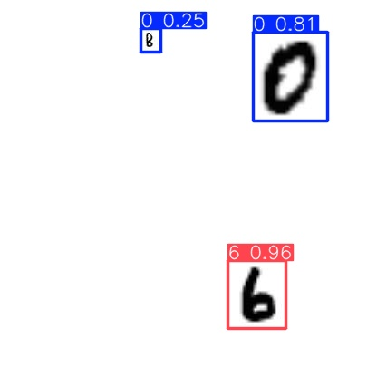

**000022_jpg.rf.d89e1085766e248c0322d57d5f1afde2.jpg**

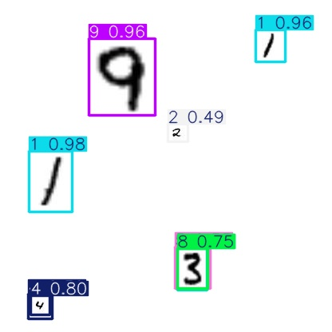

**000028_jpg.rf.52390ccbb7f3433856c47868f3123877.jpg**

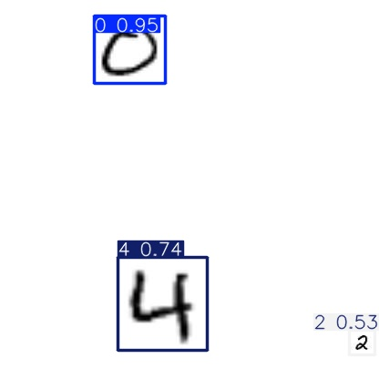

**000029_jpg.rf.13d22c3ff9130850dd6e7f5b732d195f.jpg**

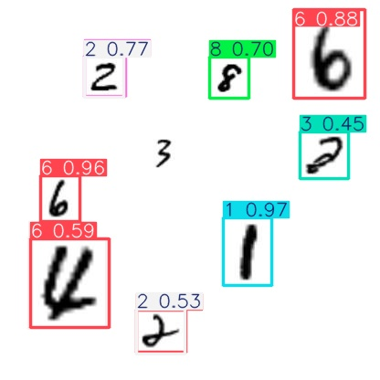

**000031_jpg.rf.fa82149c089a2e46241af4e4d1e8b013.jpg**

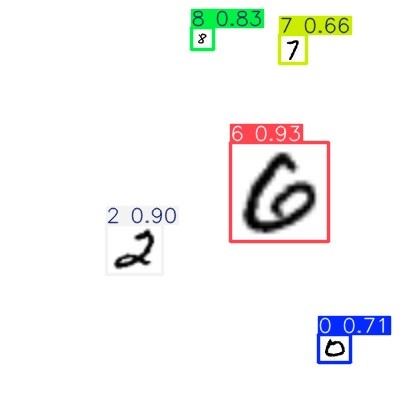

V1 No-Flip

```
folder: D:\workplace_00\runs\detect\runs\mnist_preds\v1_no_flip exists: True
```

**000006_jpg.rf.517a38906e1d34cb6aae423489bc1b4a.jpg**

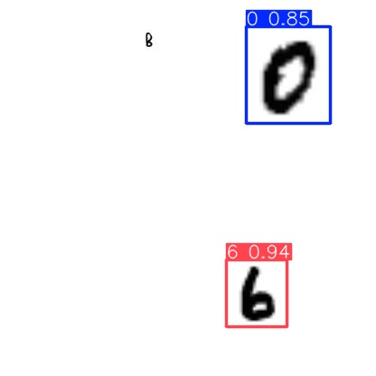

**000022_jpg.rf.d89e1085766e248c0322d57d5f1afde2.jpg**

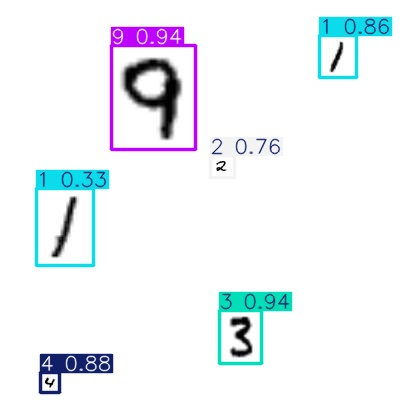

**000028_jpg.rf.52390ccbb7f3433856c47868f3123877.jpg**

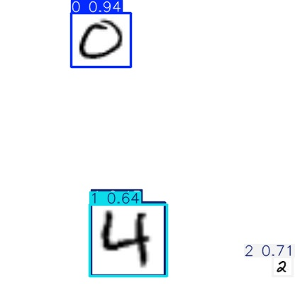

**000029_jpg.rf.13d22c3ff9130850dd6e7f5b732d195f.jpg**

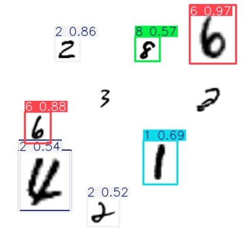

**000031_jpg.rf.fa82149c089a2e46241af4e4d1e8b013.jpg**

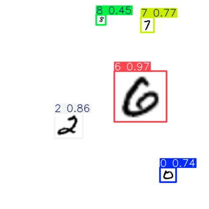

V2 No-Flip

```
folder: D:\workplace_00\runs\detect\runs\mnist_preds\v2_no_flip exists: True
```

**000006_jpg.rf.ff1519060ffac9999a9b5f57fb4de5c7.jpg**

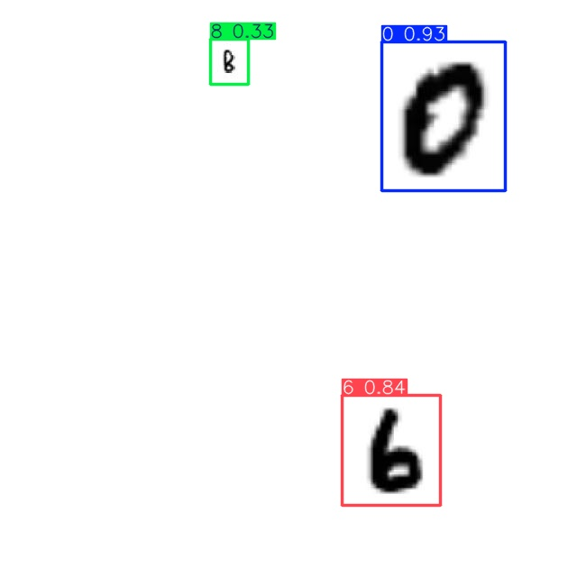

**000022_jpg.rf.057b1a75f71197b37f9b21fa28b9c45b.jpg**

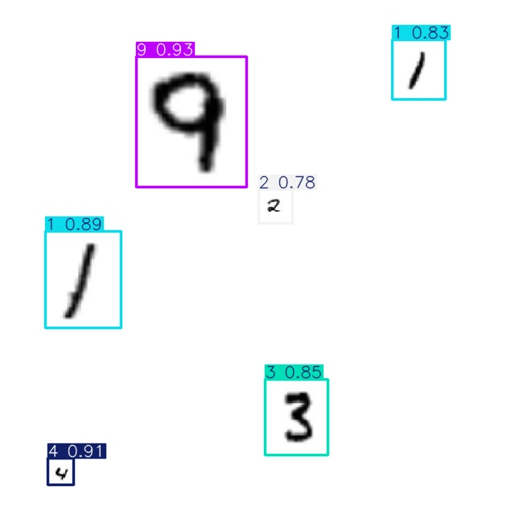

**000028_jpg.rf.996b6389031c739ace5c2560d7adbcd6.jpg**

[8 more figures not shown]

```python
from pathlib import Path
from IPython.display import display, Markdown, Image

pred_dirs = {
    "V1 Baseline": Path("./runs/detect/runs/mnist_preds/v1_baseline"),
    "V1 No-Flip": Path("./runs/detect/runs/mnist_preds/v1_no_flip"),
    "V2 No-Flip": Path("./runs/detect/runs/mnist_preds/v2_no_flip"),
    "V3 No-Flip": Path("./runs/detect/runs/mnist_preds/v3_no_flip"),
}

image_exts = {".jpg", ".jpeg", ".png", ".bmp", ".webp"}

for title, folder in pred_dirs.items():
    display(Markdown(f"## {title}"))
    print("folder:", folder.resolve(), "exists:", folder.exists())

    if not folder.exists():
        print("폴더가 없습니다.\n")
        continue

    image_files = sorted([p for p in folder.iterdir() if p.suffix.lower() in image_exts])

    if not image_files:
        print("표시할 이미지가 없습니다.\n")
        continue

    for img_path in image_files:
        display(Markdown(f"**{img_path.name}**"))
        display(Image(filename=str(img_path), width=700))
```

## Discussion

The experimental results show a clear and meaningful improvement trend across the full development process.

First, the comparison between the baseline model and the no-flip version of V1 confirmed that generic augmentation strategies are not always suitable for handwritten digit detection. Removing flip augmentation increased precision and slightly improved both mAP50 and mAP50-95, although recall decreased. This suggests that the detector became more conservative but also more reliable, which is consistent with the semantic sensitivity of handwritten digits to horizontal flipping.

Second, the Roboflow-based dataset versioning strategy contributed to further model improvement. Version 2 achieved the highest **mAP50 (0.9695)** and strong recall, indicating that the augmented dataset improved the model’s general detection capability and object coverage. This means the model was able to detect more digit instances successfully under the standard IoU criterion.

However, Version 3 produced the strongest final overall result. Although its mAP50 was slightly lower than that of Version 2, it achieved the highest **Precision (0.9174)** and the highest **mAP50-95 (0.6064)** among all experiments. These results indicate that Version 3 provided the best balance between detection reliability and localization quality.

## Conclusion

This project successfully demonstrated the development and improvement process of an MNIST-based object detection model using Roboflow and YOLO.

The workflow included:

1. dataset inspection and local configuration
2. baseline training
3. identification of an unsuitable augmentation strategy
4. retraining without flip augmentation
5. training on improved dataset versions
6. quantitative and qualitative comparison

The final results showed that different experiments improved different aspects of performance. The no-flip V1 model demonstrated the importance of task-specific augmentation control. Version 2 improved general detection performance and achieved the highest mAP50. Version 3 achieved the best overall balance and was selected as the final model because it produced the highest precision and the highest mAP50-95.

Overall, this study shows that object detection performance can be improved not only through model training itself, but also through careful dataset versioning, appropriate augmentation design, and systematic experimental comparison.

## Limitations and Future Work

This study also has several limitations.

First, the validation and test sets were relatively small, so the evaluation results should be interpreted primarily as comparative rather than absolute. Second, the experiments were conducted on a specialized handwritten digit dataset rather than a natural image detection benchmark.

For future work, the following extensions are recommended:

- increasing the dataset size
- testing larger YOLO models
- performing additional hyperparameter tuning
- analyzing class-wise failure cases in more detail
- evaluating the model on newly generated composite digit scenes